# pEMT Risk Score: Puram signature

by Henrik Schinke

22 June, 2020

# 1 Idea & Goal

The landscape of cancer biology is quite entangled, many different things do happen. More and more buzzwords seem to emerge, a big thing I do work on myself is so called [Epithelial-to-Mesenchymal Transition](https://en.wikipedia.org/wiki/Epithelial%E2%80%93mesenchymal_transition) (EMT). In a healthy setting, EMT is a program helping cells to allocate during embryonic development. Cancer seems to hijack this cellular program. Long story short; cells living happily in their tissues holding molecular hands do transition into therapy resistant invasive lone fighting colonist, that do like to migrate through the body and form new colonies (metastases) elsewhere. This might sounds like a fun analogy, but for a patient, this is very far from fun story telling and a life threatening problem. In 2017, a publication from Puram et al. described a signature for Head and Neck cancer. In this cancer type, cancer cells don’t seem to walk through the whole EMT spectrum, but just go part of the way. Therefore, Puram et al. actually described a **partial EMT (pEMT)** signature. This **pEMT signature** consists of n= 100 genes. Here, I would like to share a survival analysis making use of another great publication by [Hess et al.](https://clincancerres.aacrjournals.org/content/25/5/1505.long) describing a way to compress expression values into a **Risk Score** and apply this idea to the Puram signature. I want to show you how to compute and analyze the performance of a **pEMT Risk Score** using publicly available real world survival data from [TCGA](https://pubmed.ncbi.nlm.nih.gov/25631445/). The website [cBioPortal](https://www.cbioportal.org/) is doing a great job hosting and maintaining a variety of data sets of many different cancer types.

*Note: Large parts of data I extracted for previous projects and didn’t automate the process yet. I’ll try my best to have most things automated in the future. Further, this guide is my personal idea of combining and extrapolating different publications. Please review this with caution!*

**Research questions:**

- Do any of these genes explain survival of TCGA patients?
- Can the number of genes be reduced to 5-10 TOP candidate genes?
- Can a Risk Score be formed explaining survival data?

# 2 Import data

To extract mRNA expression data the [CGDS package](https://cran.r-project.org/web/packages/cgdsr/cgdsr.pdf) will be used. Clinical data can be extracted with e.g. the [RTCGA package](http://bioconductor.org/packages/release/bioc/html/RTCGA.html) from Bioconductor or can manually be extracted from [cbioportal](https://www.cbioportal.org/).

## 2.1 Import survival data

Survival data will be cut to 5 years of clinical follow-up. Then, survival and expression data are matched using TCGA sample ID. In Head and Neck cancer, HPV infection leads to different behavior of the disease. Thus, only HPV negative will be used for this analysis.

```
## [1] "Do genetic profile IDs and survival data IDs match?"
```

```
##
## TRUE
##  279
```

```
## [1] "Adjust survival data to 5 years follow-up"
```

```
##
## DECEASED   LIVING
##      135      144
```

```
##
## DECEASED   LIVING
##      123      156
```

```
## [1] "Remove HPV+ patients"
```

```
##
## HPV- HPV+
##  243   36
```

```
## [1] "After removal"
```

```
##
## HPV-
##  243
```

```
## [1] "Control ID match again"
```

```
##
## TRUE
##  243
```

```
## [1] "Control OS status of HPV- and make it numeric"
```

```
##
##   0   1
## 128 115
```

```
## [1] "0 = no event/ LIVING, 1 = event/ DECEASED"
```

```
##
##   0   1
## 128 115
```

# 3 EDA

## 3.1 Log2 transformation

Log2 transformation is a standard procedure for RNASeq data. Since some values were 0, 0.00001 will be added to all mRNA expression values before applying the transformation. QQ-plots of 3 random genes are shown, prior and post log2 transformation.

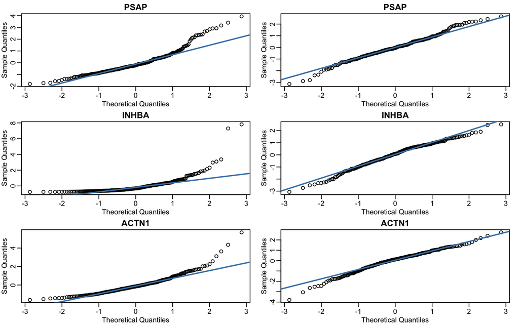

The QQ-plots show that log2 transformation adjusted the mRNA expression values towards a normal distribution. *(Sample quantiles are closer to the blue line)*

## 3.2 Correlation matrix

Visualize correlation of genes in a heatmap matrix with hierarchical clustering. High correlation would result in collinearity in Cox PH models. The metric visualized here is Spearman’s rho.

*Note: In modeling you don’t want to have high correlation of the input variables, so called features. You want to explain your data and with high correlating features you don’t add more explanation to your models.*

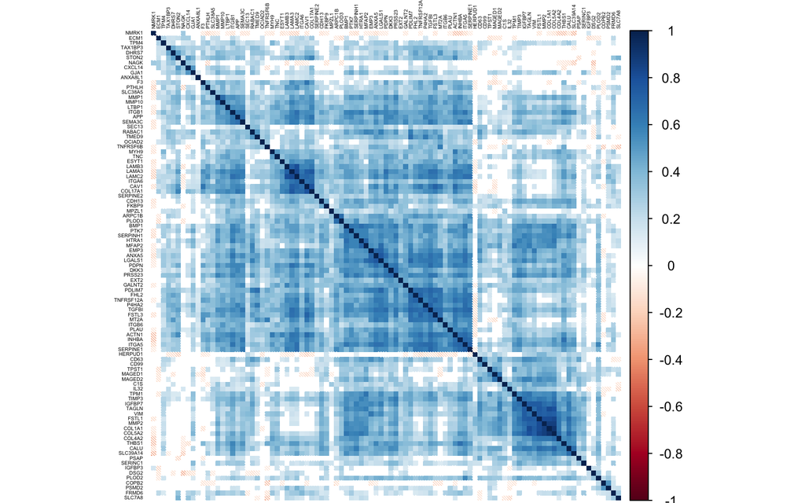

In the TCGA patients, some genes do show a high (positive) correlation. Thus, collinearity might be a problem for multivariate Cox PH models. Selected genes will later on be checked again for high correlation.

# 4 Survival models

## 4.1 Univ. Cox models

Out of the n= 100 genes from the Puram signature, n= 95 were found to be expressed in the TCGA data set. All n= 95 genes will be tested in simple univariate Cox proportional hazard (Cox PH) models. The estimate gives you the hazard ratio (HR).

*Note: In very simple words, if the HR > 1: “the more the worse” and if HR < 1; “the more the better” for the patient. The p-value tells you if the estimation (HR) for the respective gene is meaningful.*

```
## [1] "Control ID match again"
```

```
##
## TRUE
##  243
```

| term | estimate | std.error | statistic | p.value | conf.low | conf.high | signif |
| --- | --- | --- | --- | --- | --- | --- | --- |
| ANXA5 | 1.292 | 0.155 | 1.655 | 0.098 | 0.954 | 1.749 | . |
| ANXA8L1 | 0.981 | 0.012 | -1.653 | 0.098 | 0.959 | 1.004 | . |
| C1S | 0.819 | 0.085 | -2.331 | 0.020 | 0.693 | 0.969 | * |
| CD63 | 1.385 | 0.169 | 1.929 | 0.054 | 0.995 | 1.928 | . |
| COL4A2 | 0.837 | 0.106 | -1.683 | 0.092 | 0.681 | 1.030 | . |
| CXCL14 | 0.890 | 0.036 | -3.244 | 0.001 | 0.829 | 0.955 | ** |
| DSG2 | 1.287 | 0.098 | 2.584 | 0.010 | 1.063 | 1.559 | ** |
| GJA1 | 0.850 | 0.082 | -1.986 | 0.047 | 0.724 | 0.998 | * |
| IGFBP3 | 1.139 | 0.069 | 1.894 | 0.058 | 0.995 | 1.304 | . |
| NAGK | 0.778 | 0.141 | -1.783 | 0.075 | 0.590 | 1.025 | . |
| P4HA2 | 1.232 | 0.114 | 1.828 | 0.068 | 0.985 | 1.542 | . |
| PLOD2 | 1.328 | 0.098 | 2.891 | 0.004 | 1.096 | 1.609 | ** |
| PSMD2 | 1.394 | 0.188 | 1.764 | 0.078 | 0.964 | 2.016 | . |
| SLC38A5 | 0.843 | 0.048 | -3.557 | 0.000 | 0.767 | 0.926 | *** |
| TMED9 | 1.399 | 0.192 | 1.751 | 0.080 | 0.961 | 2.036 | . |
| TNFRSF6B | 1.119 | 0.067 | 1.672 | 0.095 | 0.981 | 1.278 | . |
| TPM4 | 0.700 | 0.191 | -1.863 | 0.062 | 0.481 | 1.019 | . |

### 4.1.1 Robust likelihood-based survival modeling

The [rbsurv package](https://www.bioconductor.org/packages/release/bioc/vignettes/rbsurv/inst/doc/rbsurv.pdf) is a nice way to find genes to build a multivariate Cox PH model. For simplicity, the rbsurv.default function will be applied with a set.seed= 1. Read more about this package by [Cho et al.](https://www.bioconductor.org/packages/release/bioc/vignettes/rbsurv/inst/doc/rbsurv.pdf) and it’s underlying math. Here, all genes found in the univ. Cox PH models with a p-value ≤ 0.1 will be applied.

```
## Please wait... Done.
```

```
##    Seq Order     Gene nloglik     AIC Selected
## 0    1     0        0  568.99 1137.98
## 17   1     1    PLOD2  564.56 1131.13 *
## 2    1     2     TPM4  561.09 1126.17 *
## 3    1     3 TNFRSF6B  560.25 1126.49 *
## 4    1     4  SLC38A5  555.40 1118.80 *
## 5    1     5    ANXA5  554.67 1119.34 *
## 6    1     6   CXCL14  554.18 1120.36 *
## 7    1     7     CD63  554.03 1122.07 *
## 8    1     8    P4HA2  552.42 1120.84 *
## 9    1     9      C1S  549.01 1116.03 *
## 10   1    10    PSMD2  548.80 1117.60
## 11   1    11    TMED9  548.33 1118.67
## 12   1    12     GJA1  548.31 1120.63
## 13   1    13     DSG2  548.31 1122.62
## 14   1    14   COL4A2  546.77 1121.54
## 15   1    15     NAGK  546.68 1123.36
## 16   1    16  ANXA8L1  544.91 1121.82
```

```
## [1] "Genes selected by RB survival modeling"
```

```
## [1] "PLOD2"    "TPM4"     "TNFRSF6B" "SLC38A5"  "ANXA5"    "CXCL14"   "CD63"
## [8] "P4HA2"    "C1S"
```

#### 4.1.1.1 Visualization

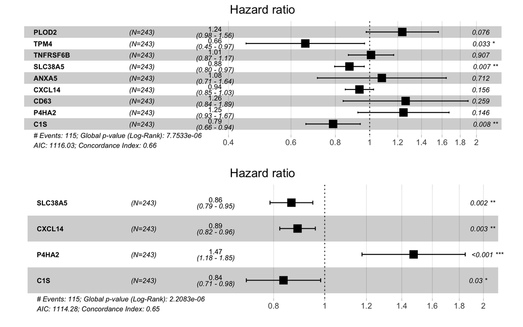

#### 4.1.1.2 Correlation

A correlation matrix of selected genes to control for collinearity of in the final Cox PH model.

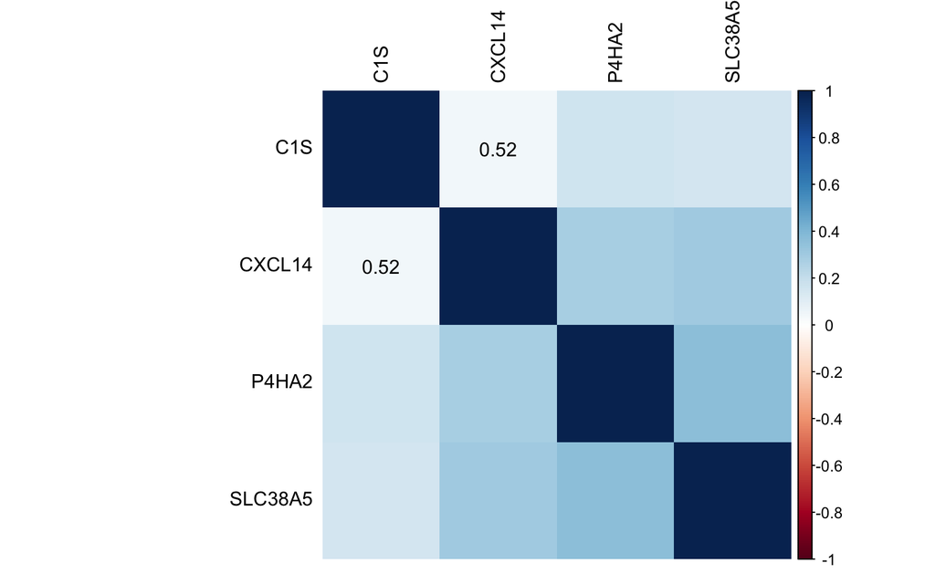

There seem to be low chances of collinearity within the genes of the selected Cox model.

# 5 Risk Score

Now, 4 genes could be selected out of the n= 95 genes from the pEMT signature by Puram et al. As aforementioned, a Risk Score based on the coefficients in the multivariate Cox model will be computed. Then, it will be tested if this **pEMT Risk Score** is predictive of clinical TCGA patient data. To keep things simple and visualize the analysis, the **pEMT Risk Score** will be binarized based on the median value over all n= 243 TCGA patients. So, all patients will be grouped into **low Risk (Risk-)** or **high Risk (Risk+)**. A Cox PH model will be assessed again and a Kaplan Meier curve will visualize the final results.

```
## [1] "Coefficients of genes forming Risk Score"
```

```
##    SLC38A5     CXCL14      P4HA2        C1S
## -0.1454541 -0.1186142  0.3882853 -0.1800200
```

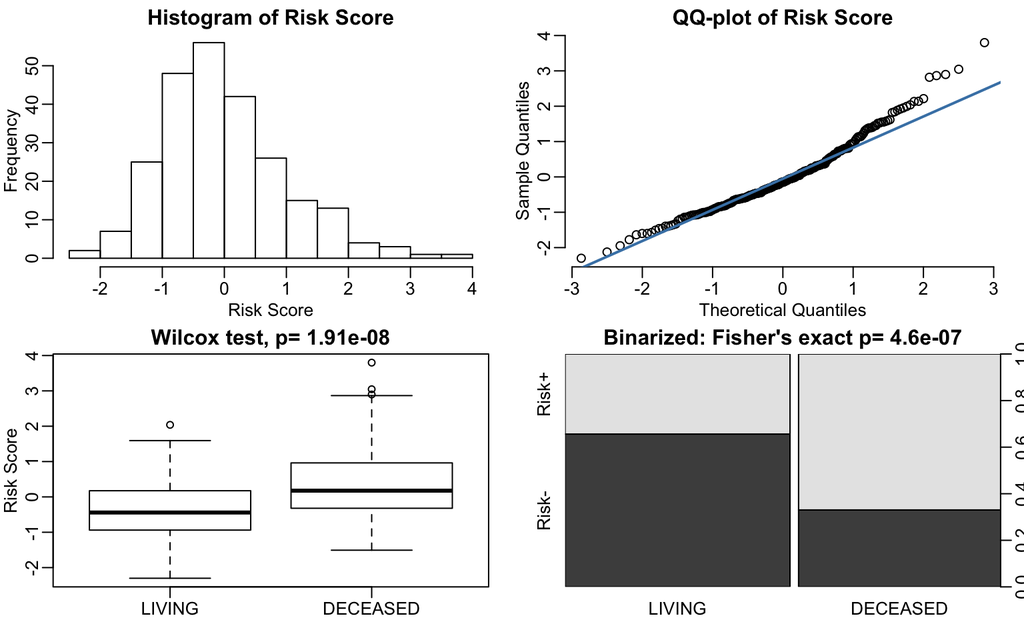

The computed Risk Score seems to be more or less normally distributed with a right tail. Patients without an event over 5 years of follow-up had significantly lower levels of the **pEMT Risk Score**. This was further reflected in the distribution of the grouped patients.

## 5.1 Survival models

```
## [1] "Continous Cox PH model with Risk Score as feature"
```

```
## Call:
## coxph(formula = Surv(time = Time.OS, event = Status.OS) ~ RiskScore,
##     data = ALL)
##
##   n= 243, number of events= 115
##
##              coef exp(coef) se(coef)     z Pr(>|z|)
## RiskScore 0.48682   1.62713  0.08148 5.974 2.31e-09 ***
## ---
## Signif. codes:  0 '***' 0.001 '**' 0.01 '*' 0.05 '.' 0.1 ' ' 1
##
##           exp(coef) exp(-coef) lower .95 upper .95
## RiskScore     1.627     0.6146     1.387     1.909
##
## Concordance= 0.652  (se = 0.025 )
## Likelihood ratio test= 31.69  on 1 df,   p=2e-08
## Wald test            = 35.69  on 1 df,   p=2e-09
## Score (logrank) test = 36.26  on 1 df,   p=2e-09
```

```
## [1] "Binarized Risk Score visualized with a Kaplan Meier"
```

```
## Call:
## coxph(formula = Surv(time = Time.OS, event = Status.OS) ~ RiskBin,
##     data = ALL)
##
##   n= 243, number of events= 115
##
##                coef exp(coef) se(coef)     z Pr(>|z|)
## RiskBinRisk+ 0.9202    2.5098   0.1988 4.628 3.69e-06 ***
## ---
## Signif. codes:  0 '***' 0.001 '**' 0.01 '*' 0.05 '.' 0.1 ' ' 1
##
##              exp(coef) exp(-coef) lower .95 upper .95
## RiskBinRisk+      2.51     0.3984       1.7     3.706
##
## Concordance= 0.605  (se = 0.024 )
## Likelihood ratio test= 23  on 1 df,   p=2e-06
## Wald test            = 21.42  on 1 df,   p=4e-06
## Score (logrank) test = 22.94  on 1 df,   p=2e-06
```

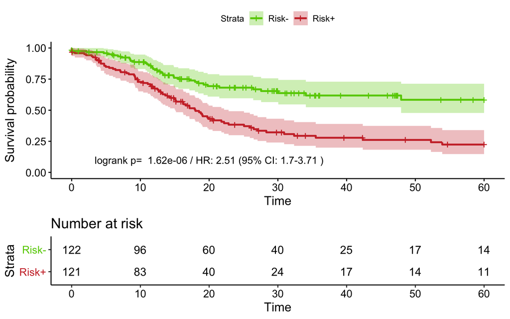

## 5.2 Primary sites

Risk Score and tumor primary site will be assessed to see if the **pEMT Risk Score** might be a surrogate for localization of primary tumor sites. Since Hypopharynx and Oropharynx account for low patient numbers, these primary sites will be excluded from analysis for simplicity.

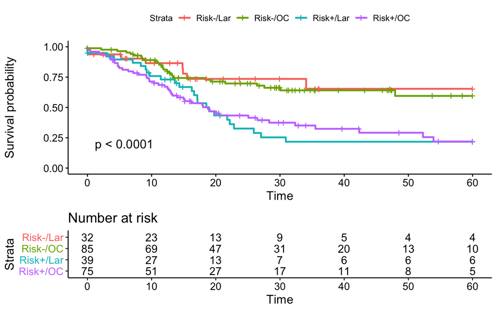

|  | RiskBin=Risk-, PrimSite=Lar | RiskBin=Risk-, PrimSite=OC | RiskBin=Risk+, PrimSite=Lar |
| --- | --- | --- | --- |
| RiskBin=Risk-, PrimSite=OC | ns |  |  |
| RiskBin=Risk+, PrimSite=Lar | * | ** |  |
| RiskBin=Risk+, PrimSite=OC | * | *** | ns |

The **pEMT Risk Score** seems not to be a surrogate for localization of primary tumor sites because all patients were simply stratified after their Risk Score group. No differences between the tumor primary sites are seen. A pairwise logrank comparison confirms these findings.

## 5.3 DFS and RiskScore

Disease-free survival over 3 years will be investigated to see if the **pEMT Risk Score** is able to stratify the patients according to this clinical endpoint, too.

[output not shown]

```
## Call:
## coxph(formula = Surv(time = DFS.Time, event = DFS.Status) ~ RiskScore)
##
##   n= 100, number of events= 43
##
##             coef exp(coef) se(coef)     z Pr(>|z|)
## RiskScore 0.4417    1.5553   0.1249 3.536 0.000406 ***
## ---
## Signif. codes:  0 '***' 0.001 '**' 0.01 '*' 0.05 '.' 0.1 ' ' 1
##
##           exp(coef) exp(-coef) lower .95 upper .95
## RiskScore     1.555      0.643     1.218     1.987
##
## Concordance= 0.629  (se = 0.047 )
## Likelihood ratio test= 10.46  on 1 df,   p=0.001
## Wald test            = 12.5  on 1 df,   p=4e-04
## Score (logrank) test = 12.69  on 1 df,   p=4e-04
```

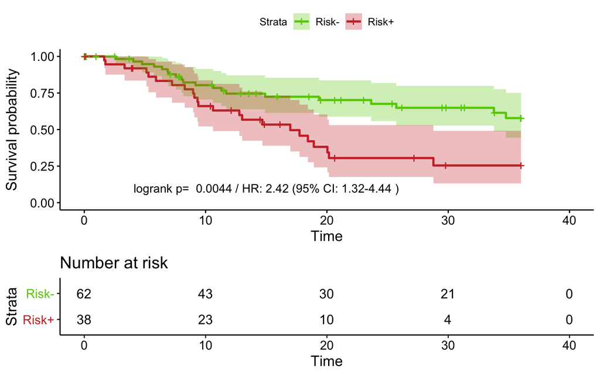

# 6 Conclusions

**Initial research questions:**

Out of the n= 100 pEMT genes described by Puram et al., n= 95 were found to be measured in the TCGA patient cohort. A univariate Cox PH analysis did result in n= 6 genes with explanatory power for the survival data. A final multivariate Cox PH model consisting of the n= 4 genes; SLC38A5, CXCL14, P4HA2, C1S was computed. Using the coefficients of those genes, a Risk Score associated with pEMT was calculated. The computed **pEMT Risk Score** has explanatory power and could be used to allocate patients to low and high Risk subgroups (Risk- and Risk+). Further, the **pEMT Risk Score** is not a surrogate for tumor primary sites and was able to explain Disease-free survival, too.

## 6.1 Critical assessment

So, indeed the initial research questions could be answered. An explanatory **pEMT Risk Score** was computed and gene candidates with clinical relevance were extracted. Interestingly, 3 out 4 genes forming the Risk Score did have < 0 coefficients in the multivariate Cox PH model. If we assume Puram et al. described genes with a (positive) correlation to pEMT and pEMT is a negative prognosticator, this is probably contradicting because a negative coefficient, so an HR < 1, means “the more the better for the patient”. So, for 3 out 4 genes we would assume a low Risk of pEMT if the genes are highly expressed in a patient. This is not necessarily a neck breaker for this analysis but it definitely means that further investigations of those selected genes are needed to explain this biologically. After all, the TCGA data set is great but a temporary snapshot of patients’ gene expression. We do not have any information about temporal resolution etc.

*Note: This is the illustrative Guide for the analysis. Please find the actual R-Script with further annotations and data sets on my [Github](https://github.com/HenrikSchinke/RiskScore_pEMT). If you would like to know more about Cox PH models take a look [here](http://www.sthda.com/english/wiki/cox-proportional-hazards-model)*